# Learning SQL from Udemy Course: The Complete SQL Bootcamp

Joshua Timm

10/24/2019

To easily connect to sql later on, we can setup a connection to a locally hosted SQL database with the following `R` setup code, with information such as `password`, `dbname`, `host`, `port`, `user` changed to match yours.

```r
knitr::opts_chunk$set(echo = TRUE)
require("RPostgreSQL")
# create a connection
pw <- {"ya_password"}
# loads the PostgreSQL driver
drv <- dbDriver("PostgreSQL")
# creates a connection to the postgres database
# note that "con" will be used later in each connection to the database
con <- dbConnect(drv, dbname = "dvdrental",
                 host = "localhost", port = 5432,
                 user = "me", password = pw)
#rm(pw) # removes the password
library(reticulate)
use_python(python = '/Users/joshuatimm/opt/anaconda3/bin/python')
```

## SELECT

The SELECT function is used to simply get data from various tables.

## SELECT CHALLENGE

We want to send out a promotional email to our existing customers, so we want their emails and their names.

*Challenge* = we want to grab the first name, last name, and email address of each customer.

```sql
SELECT first_name, last_name, email FROM customer;
```

Displaying records 1 - 10

| first_name | last_name | email |
| --- | --- | --- |
| Jared | Ely | jared.ely@sakilacustomer.org |
| Mary | Smith | mary.smith@sakilacustomer.org |
| Patricia | Johnson | patricia.johnson@sakilacustomer.org |
| Linda | Williams | linda.williams@sakilacustomer.org |
| Barbara | Jones | barbara.jones@sakilacustomer.org |
| Elizabeth | Brown | elizabeth.brown@sakilacustomer.org |
| Jennifer | Davis | jennifer.davis@sakilacustomer.org |
| Maria | Miller | maria.miller@sakilacustomer.org |
| Susan | Wilson | susan.wilson@sakilacustomer.org |
| Margaret | Moore | margaret.moore@sakilacustomer.org |

## SELECT DISTINCT

```sql
SELECT DISTINCT release_year FROM film;
SELECT DISTINCT actor FROM actor;
SELECT DISTINCT rental_rate FROM film;
SELECT DISTINCT rental_rate FROM film;
```

3 records

| rental_rate |
| --- |
| 2.99 |
| 4.99 |
| 0.99 |

## SELECT DISTINCT CHALLENGE

We want to know the types of ratings movies can get in the United states, such as PG, PG-13, etc. We want to know the types of rating types the movies in our database can have.

```sql
SELECT DISTINCT rating FROM film;
```

5 records

| rating |
| --- |
| NC-17 |
| G |
| PG |
| PG-13 |
| R |

So there’s G, PG, PG-13, R, and NC-17. Looks like all the ratings are covered in this database of movies.

## SELECT WHERE

We already know how to query data from a table in a database. BUt what if we want to query just particular rows form a table matching some sort of condition? Use the `WHERE` clause in the `SELECT` statement.

Example: `SELECT` column_1, column_2… column_n `WHERE` conditions;

The conditions are used to filter the rows returned from the `SELECT` statement.

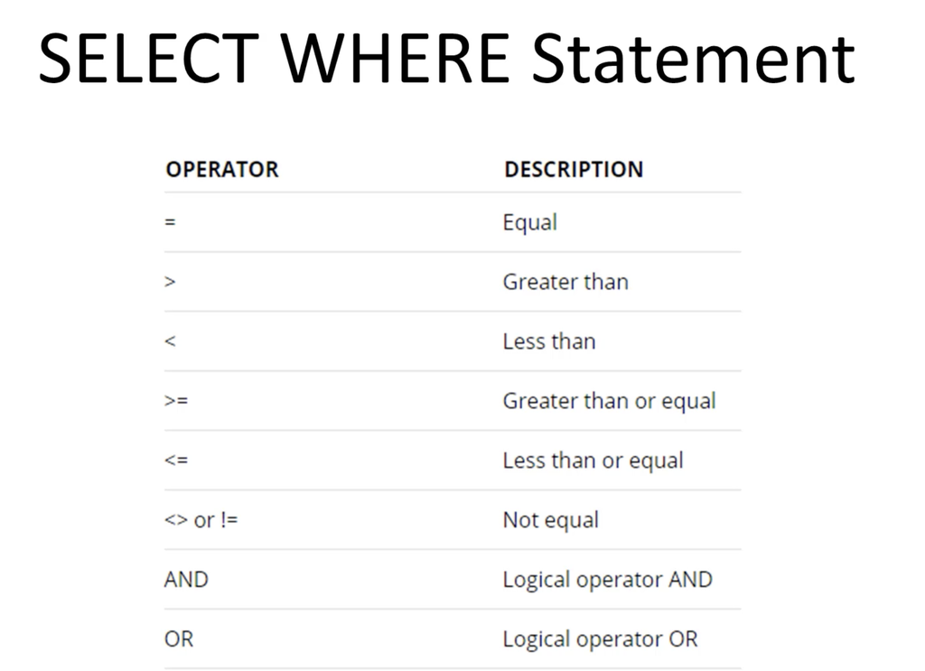

So if you want to get all customers whose names are jamie, you can use the WHERE with the `=` operator like so:

```sql
SELECT last_name, first_name FROM customer WHERE first_name = 'Jamie';
```

2 records

| last_name | first_name |
| --- | --- |
| Rice | Jamie |
| Waugh | Jamie |

Imagine you want to select a customer whose `first_name` is jamie and whose `last_name` is rice.

```sql
SELECT last_name, first_name FROM customer WHERE first_name = 'Jamie' AND last_name = 'Rice';
```

1 records

| last_name | first_name |
| --- | --- |
| Rice | Jamie |

Imagine you want to know who paid a rental amount either less than $1 or greater than $8, you can use the OR operator.

```sql
SELECT customer_id, amount, payment_date FROM payment WHERE amount <= 1 OR amount >= 8;
```

Displaying records 1 - 10

| customer_id | amount | payment_date |
| --- | --- | --- |
| 343 | 0.99 | 2007-02-17 01:26:00 |
| 343 | 0.99 | 2007-02-17 04:32:51 |
| 343 | 8.99 | 2007-02-20 07:03:29 |
| 343 | 0.99 | 2007-02-21 14:42:28 |
| 344 | 0.99 | 2007-02-16 14:00:38 |
| 345 | 0.99 | 2007-02-15 01:26:17 |
| 345 | 0.99 | 2007-02-16 00:27:01 |
| 347 | 8.99 | 2007-02-16 12:40:18 |
| 347 | 0.99 | 2007-02-18 04:59:41 |
| 347 | 8.99 | 2007-02-20 14:33:08 |

Let’s play around a lil.

```sql
SELECT email FROM customer
WHERE first_name = 'Jared';
-- note the variable you condition on, WHERE first_name = 'Jared', doesn't have to be in the return variable you select
SELECT * from payment
WHERE amount = 7.99;
-- let's explore a few more logical operators
SELECT * FROM payment
WHERE amount <5;

SELECT * FROM payment
WHERE amount <= 4.99;

SELECT amount, payment_date FROM payment WHERE amount != 4.99;
-- returns all columns where amounts are not equal to 4.99
```

Displaying records 1 - 10

| amount | payment_date |
| --- | --- |
| 7.99 | 2007-02-15 22:25:46 |
| 1.99 | 2007-02-16 17:23:14 |
| 7.99 | 2007-02-16 22:41:45 |
| 2.99 | 2007-02-19 19:39:56 |
| 7.99 | 2007-02-20 17:31:48 |
| 5.99 | 2007-02-21 12:33:49 |
| 5.99 | 2007-02-17 23:58:17 |
| 5.99 | 2007-02-20 02:11:44 |
| 2.99 | 2007-02-20 13:57:39 |
| 6.99 | 2007-02-16 01:15:33 |

The `AND` operator allows us to combine multiple conditions

```sql
SELECT * from CUSTOMER WHERE store_id = 1 AND address_id > 5;
SELECT * FROM CUSTOMER WHERE store_id = 1 OR store_id = 2;
--of course, we can't use AND everywhere, like if it doesn't make sense:
SELECT * FROM customer WHERE store_id = 1 AND store_id = 2;
-- we can't do this because an observation won't have a store id of both 1 and 2 - it doesn't make sense.
```

## SELECT WHERE Challenge

*Prompt:*A customer forgot their wallet at our store! We need to track down their email to inform them. What’s the email for the customer with the name Nancy Thomas?

```sql
SELECT email FROM customer WHERE first_name = 'Nancy' AND last_name = 'Thomas';
```

1 records

| email |
| --- |
| nancy.thomas@sakilacustomer.org |

*Prompt:* A customer wants to know what the movie ‘Outlaw Hanky’ is about: Can you get them the description for the movie?

```sql
SELECT description FROM film WHERE title = 'Outlaw Hanky';
```

1 records

| description |
| --- |
| A Thoughtful Story of a Astronaut And a Composer who must Conquer a Dog in The Sahara Desert |

And there we have it, a delightfully odd description for a movie that I’m now kind of interested in.

*Prompt:* A customer is late on their movie return. I know their address is ‘259 Ipoh Drive’. I want to call them to let them know they’re late. Can you get me the phone number for the person who lives at ‘259 Ipoh Drive’?

```sql
SELECT phone FROM address WHERE address = '259 Ipoh Drive';
```

1 records

| phone |
| --- |
| 419009857119 |

## COUNT

The `COUNT` function returns the number of input rows that match a specific condition of a query. Basically it counts the rows where the condition is true.

```sql
SELECT COUNT(*) FROM address;
SELECT COUNT(phone) FROM address;
```

1 records

| count |
| --- |
| 603 |

Keep in mind that `COUNT` does not consider `NULL` values in the column. We can also do `SELECT DISTINCT` FOR EXAMPLE:

`SELECT COUNT(DISTINCT COLUMN) FROM TABLE;` and that will count the number of particular rows for that column.

`COUNT` is a very **fast** function.

```sql
SELECT COUNT(*) FROM payment;
SELECT * FROM payment;
SELECT COUNT(DISTINCT amount) FROM payment;
SELECT COUNT(DISTINCT(amount)) FROM payment; -- parentheses also work
-- counting the DISTINCT amount types from the payment table
```

1 records

| count |
| --- |
| 19 |

We’ll revisit `COUNT` a lot and it’s going to be useful when we learn `GROUP BY` clauses.

## LIMIT

`LIMIT` allows you to limit the number of rows you get back after a query. Useful when wanting to get many columns, but now many rows. It works well by placing it at the end of a query.

```sql
SELECT title, description, release_year, length, rating  FROM film LIMIT 3;
```

3 records

| title | description | release_year | length | rating |
| --- | --- | --- | --- | --- |
| Chamber Italian | A Fateful Reflection of a Moose And a Husband who must Overcome a Monkey in Nigeria | 2006 | 117 | NC-17 |
| Grosse Wonderful | A Epic Drama of a Cat And a Explorer who must Redeem a Moose in Australia | 2006 | 49 | R |
| Airport Pollock | A Epic Tale of a Moose And a Girl who must Confront a Monkey in Ancient India | 2006 | 54 | R |

## ORDER

When you query data from a table, PostGRESQL returns rows in the order that they were inserted into the table. If you want to sort the resulting set, you can use the `ORDER BY` clause in conjunction with the `SELECT` statement. The `ORDER BY` clause allows you to sort the rows returned from the `SELECT` statement in ascending or descending order based on criteria specified.

```sql
SELECT title, description, release_year, length FROM FILM ORDER BY title ASC LIMIT 10;
SELECT title, description, release_year, length FROM FILM ORDER BY title DESC LIMIT 10;
```

Displaying records 1 - 10

| title | description | release_year | length |
| --- | --- | --- | --- |
| Zorro Ark | A Intrepid Panorama of a Mad Scientist And a Boy who must Redeem a Boy in A Monastery | 2006 | 50 |
| Zoolander Fiction | A Fateful Reflection of a Waitress And a Boat who must Discover a Sumo Wrestler in Ancient China | 2006 | 101 |
| Zhivago Core | A Fateful Yarn of a Composer And a Man who must Face a Boy in The Canadian Rockies | 2006 | 105 |
| Youth Kick | A Touching Drama of a Teacher And a Cat who must Challenge a Technical Writer in A U-Boat | 2006 | 179 |
| Young Language | A Unbelieveable Yarn of a Boat And a Database Administrator who must Meet a Boy in The First Manned Space Station | 2006 | 183 |
| Yentl Idaho | A Amazing Display of a Robot And a Astronaut who must Fight a Womanizer in Berlin | 2006 | 86 |
| Wyoming Storm | A Awe-Inspiring Panorama of a Robot And a Boat who must Overcome a Feminist in A U-Boat | 2006 | 100 |
| Wrong Behavior | A Emotional Saga of a Crocodile And a Sumo Wrestler who must Discover a Mad Cow in New Orleans | 2006 | 178 |
| Wrath Mile | A Intrepid Reflection of a Technical Writer And a Hunter who must Defeat a Sumo Wrestler in A Monastery | 2006 | 176 |
| Worst Banger | A Thrilling Drama of a Madman And a Dentist who must Conquer a Boy in The Outback | 2006 | 185 |

And interesting here, we learn there is a movie named ‘Zorro Ark’, which is likely where the name of the Pokémon Zoroark comes from.

Specify the column that you want to sort in the `ORDER BY` clause. If you sort the result set by multiple columns, use a comma to separate between two columns. If you leave it blank, it uses `ASC` by default.

```sql
SELECT first_name, last_name FROM customer ORDER BY first_name ASC;
SELECT first_name, last_name FROM customer ORDER BY first_name ASC, last_name DESC;
```

Displaying records 1 - 10

| first_name | last_name |
| --- | --- |
| Aaron | Selby |
| Adam | Gooch |
| Adrian | Clary |
| Agnes | Bishop |
| Alan | Kahn |
| Albert | Crouse |
| Alberto | Henning |
| Alex | Gresham |
| Alexander | Fennell |
| Alfred | Casillas |

So this last query sorts the `first_name` column in ascending order, and the `last_name` column in descending order. So your results are FIRST being sorted by the first names, so you’re going to start with Aarons and go to Zekes. But also, if there’s Aaron Zoroak and Aaron Yveltal, you’re going to get Aaron Zoroark before Aaron Yveltal.

Postgresql also allows you to sort by columns even if they’re not selected. Other ANSI SQL formats may not let you do this. Most standard sql queries will only allow you to sort rows that appear in the SELECT clause.

```sql
SELECT first_name, last_name FROM customer ORDER BY last_name;
```

Displaying records 1 - 10

| first_name | last_name |
| --- | --- |
| Rafael | Abney |
| Nathaniel | Adam |
| Kathleen | Adams |
| Diana | Alexander |
| Gordon | Allard |
| Shirley | Allen |
| Charlene | Alvarez |
| Lisa | Anderson |
| Jose | Andrew |
| Ida | Andrews |